# Comparison of Nup related genes and Robson LADs / Belmont SPIN classification

## Robson LADs first

```
## [1] 42
```

```
## [1] 0
```

```
## [1] 0
```

```
## [1] 0
```

1. Overlap of Nup related genes and LADs

If there is any overlap between Nup gene and LAD the data point is treated as LAD. RMCs are randomly chosen protein coding genes with sample size == 486.

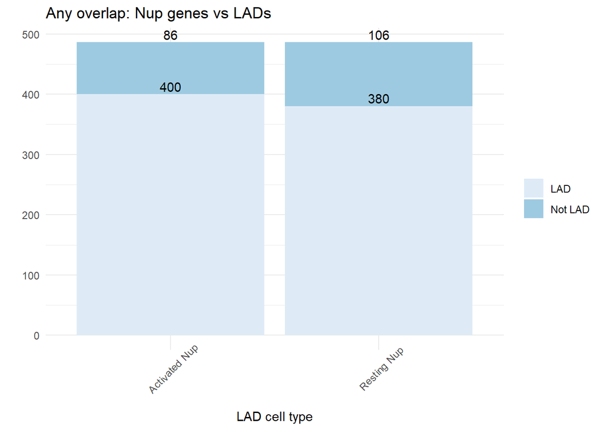

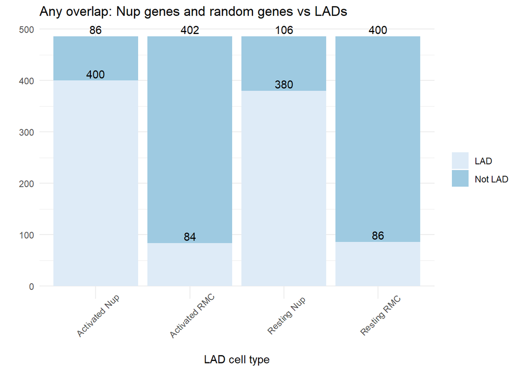

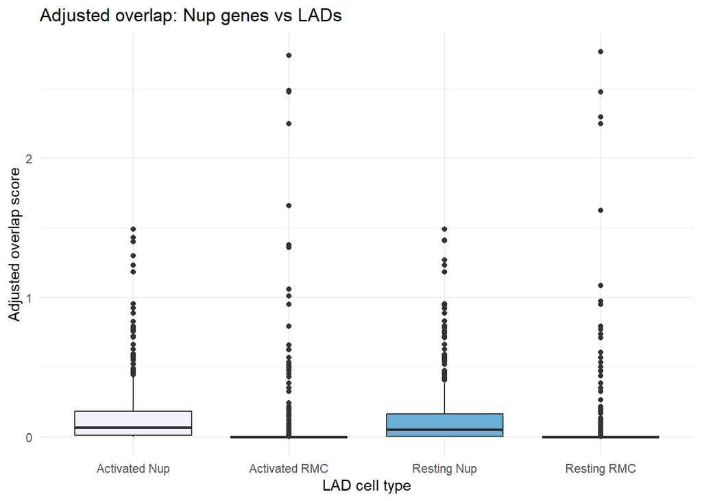

2. Overview of the interaction between intron/exon split in Nup genes and Robson LADs.

Percentatge overlap thats in exons for genes that have any overlap at all; the Nup gene overlap is mostly intronal:

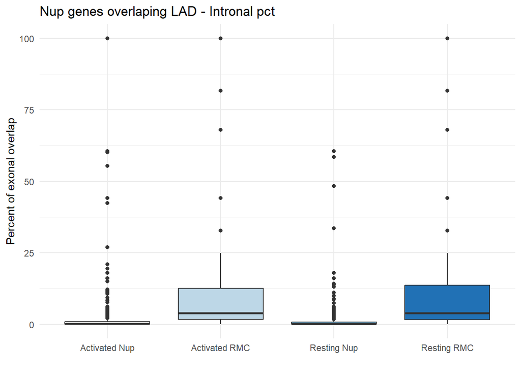

```r
# calculate percentage of the overlap thats exonal
Robson_LADs_vs_Nups[isLAD == "LAD",pct_exon := 100*LAD_exon /(LAD_exon + LAD_intron)]
Robson_LADs_vs_Nups_RMCs[isLAD == "LAD",pct_exon := 100*LAD_exon /(LAD_exon + LAD_intron)]
withRMC2 <- rbind(Robson_LADs_vs_Nups,Robson_LADs_vs_Nups_RMCs)
p4 <- ggplot(withRMC2[isLAD == "LAD",]
, aes(y = (pct_exon), x=LAD_type, fill =LAD_type)) +
  geom_boxplot()+
  scale_fill_brewer(palette="Blues", direction = 1)+ theme(axis.ticks.y = element_blank())+
  theme(axis.text.x = element_text(angle = 45, vjust = 0.8, hjust=0.5))+
  labs(x = "",
       y = "Percent of exonal overlap",
       fill = "",
       title = "Nup genes overlaping LAD - Intronal pct")+theme_minimal()+theme(legend.position = "none")
p4
```

3. Comparison of above with HIV integrations

More integrations i Nup genes than random gene sample. Also Robson LADs overlapping genes seem to have small increase in KO153 group integrations.

The recurrent integrations graph isnt adjusted for different group sizes yet (NT is about te same size as KO62 and KO153 together by number of integrations). This is unlikely to explain all of the variance betwen them.

No real difference in percentage of exonal integrations overlapping Activated or Resting LADs, but randomly selected genes have integratiosn fall in more exonal LAD overlaps.

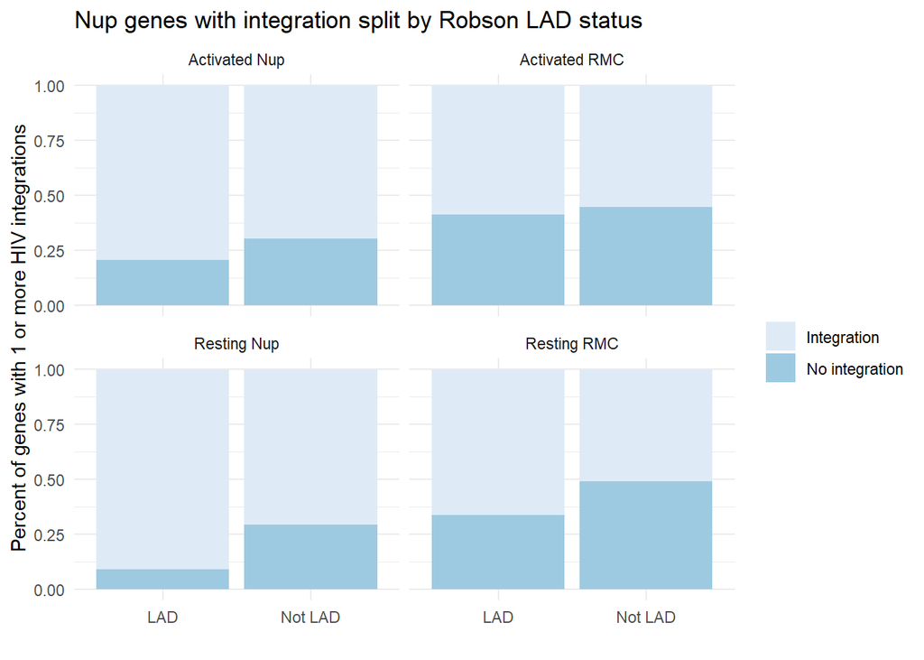

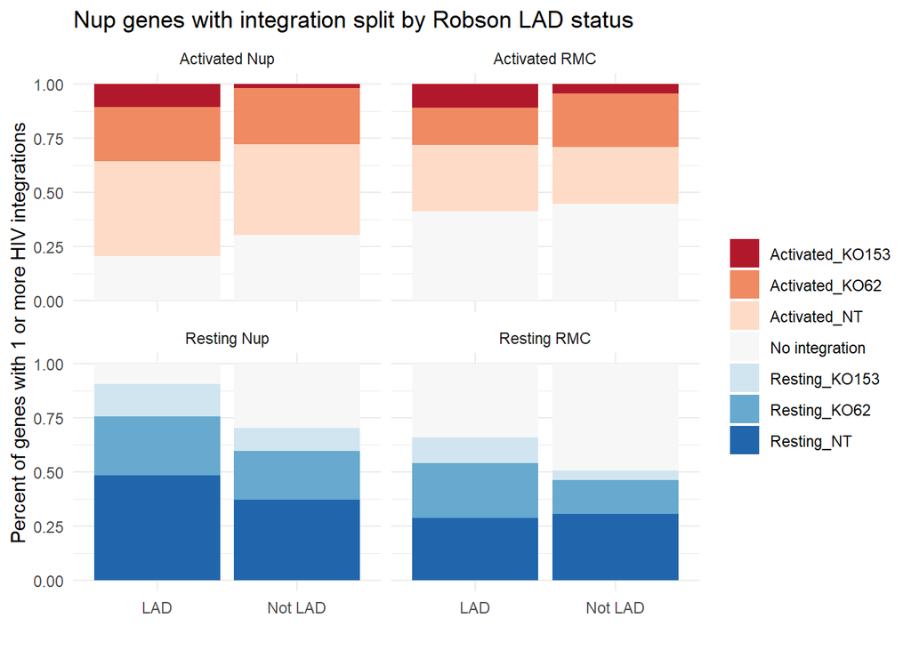

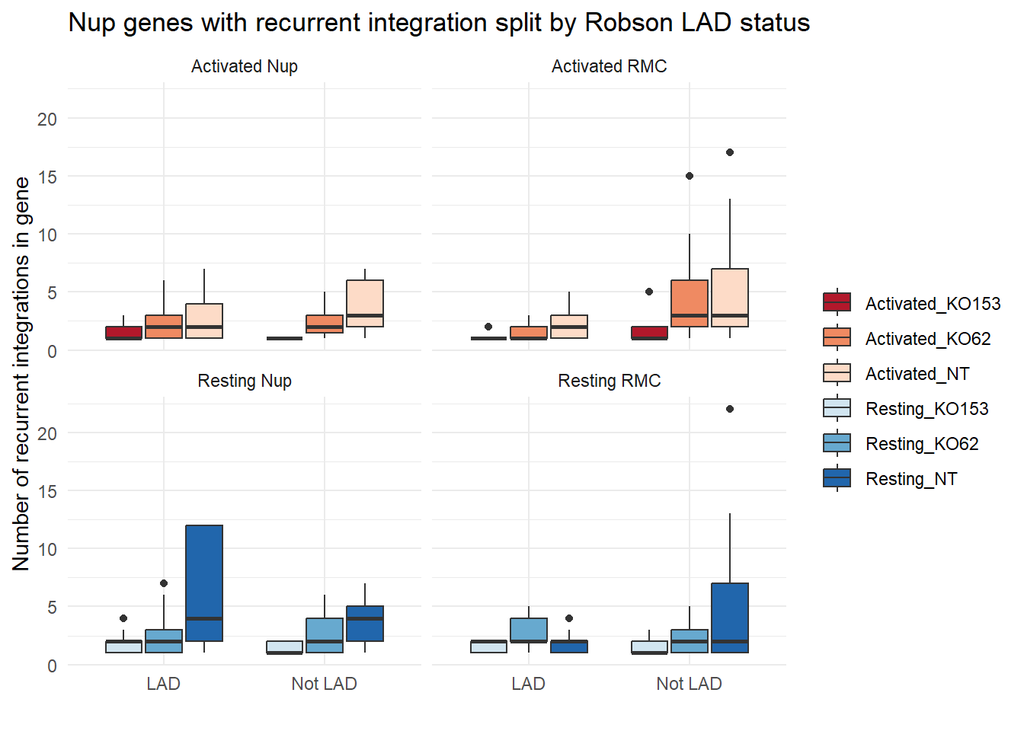

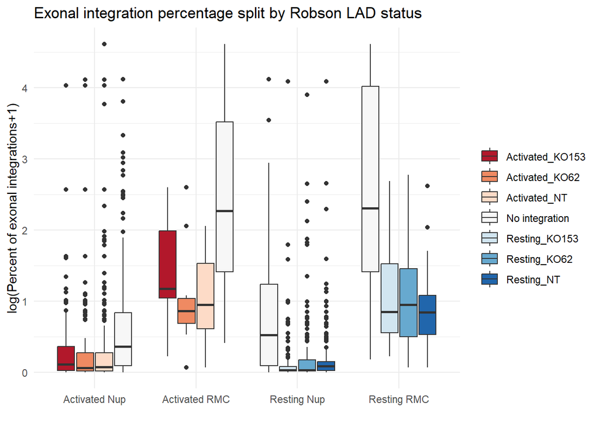

## Belmont SPIN clasification vs Nup genes

4 nup genes have no overlap with the Belmont Spin classifiction “CISD1” “FAM74A2” “INTS4L2” “ANKRD20A14P”

Comparison to randomly selected genes shows avoidance of Speckles and first two interior active compartments.

```
## [1] 756
```

```
## [1] 814
```

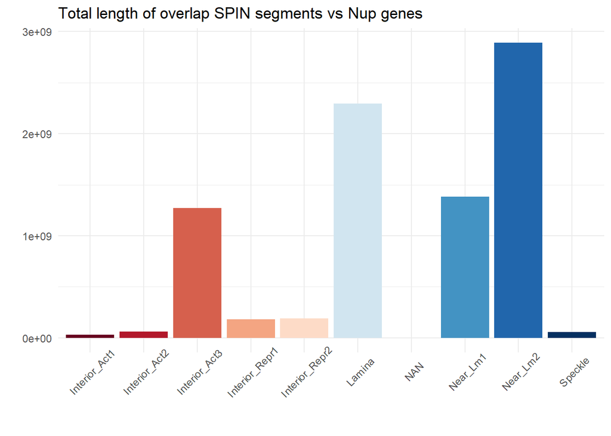

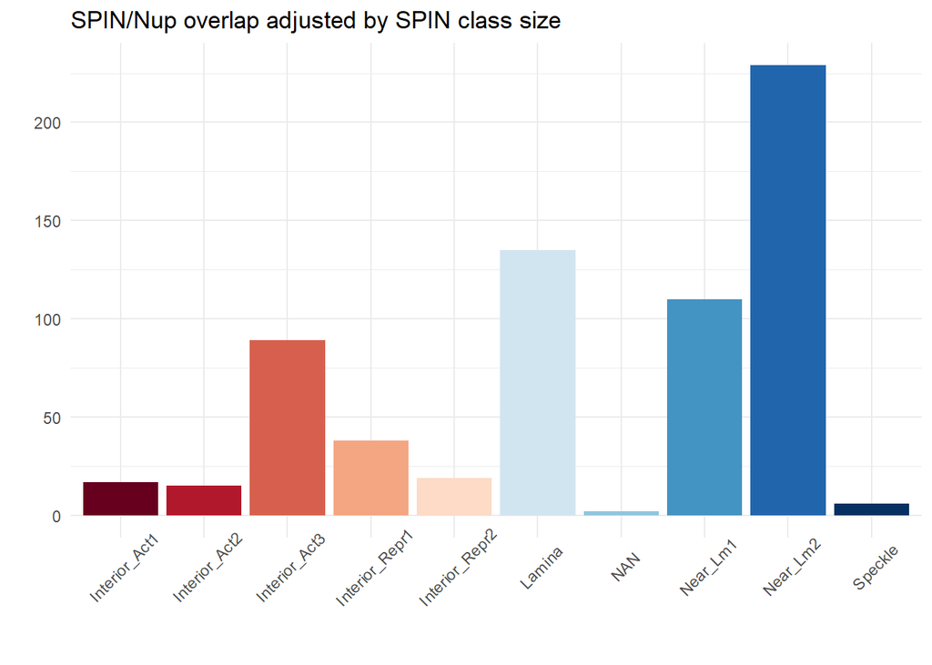

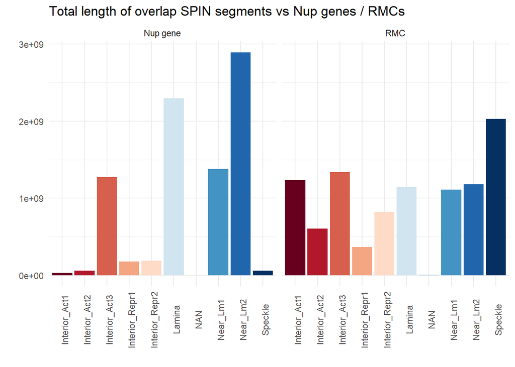

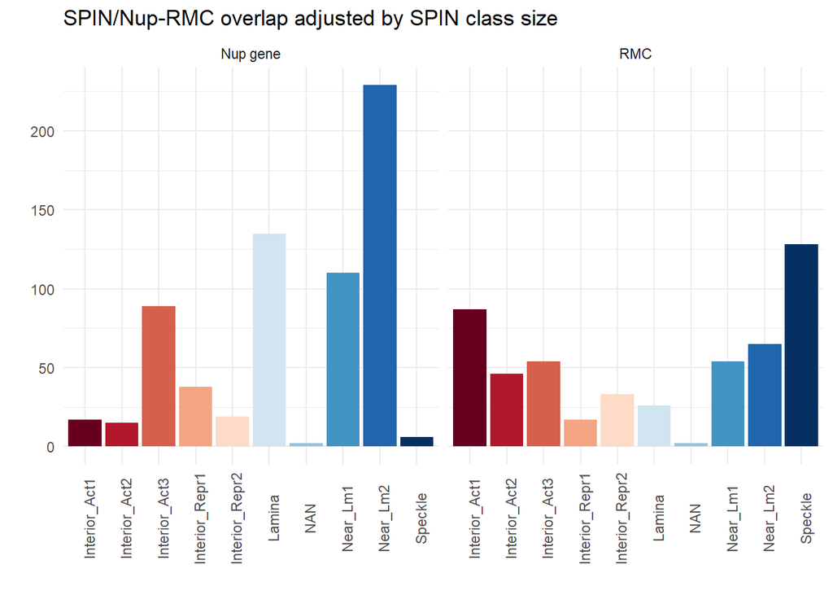